# CLIMATE 405: Machine Learning for Earth and Environmental Sciences; FALL 2024

## Mohammed Ombadi (ombadi@umich.edu)

# Lecture 15 (Monday, 10/28/2024)

# Topics covered in this lecture:

- Revisit the RNN example from Lec 14.
- Techniques used in training of ML models: Validation Data Split, Dropout.
- The vanishing/exploding gradient problem.
- In-class Excercise (Applying RNNs to the monthly_meteo_streamflow.csv dataset)

## Import libraries

```python
# Import libraries
import os
import sys
import numpy as np
import pandas as pd
import matplotlib.pyplot as plt
import seaborn as sns
import plotly.graph_objects as go
import plotly.express as px
import warnings

from scipy.integrate import odeint
from IPython.display import Image

# Sklearn specific functions used in this lecture
from sklearn.model_selection import train_test_split
from sklearn.preprocessing import LabelEncoder
from sklearn.tree import DecisionTreeClassifier, DecisionTreeRegressor
from sklearn.ensemble import RandomForestRegressor
from sklearn.metrics import classification_report, confusion_matrix
from sklearn.tree import plot_tree
from sklearn.metrics import mean_squared_error, r2_score

# Shapley Interpretation
import shap

# Tensorflow
import tensorflow as tf
from tensorflow.keras.models import Sequential
from tensorflow.keras.layers import SimpleRNN, Dense, Flatten, Dropout
from tensorflow.keras.utils import plot_model

# Suppress warnings
warnings.filterwarnings('ignore')

# Set number of decimals for np print options
np.set_printoptions(precision=3)

# Set the current working directory
os.chdir(sys.path[0])
```

## Revisit the RNN example from Lec 14

In Lecture 14, we buit a Recurrent Neural Network model (rnn_model) and compared its performance to a Multilayer Perceptron model (mlp_model). Below are the two models summaries:

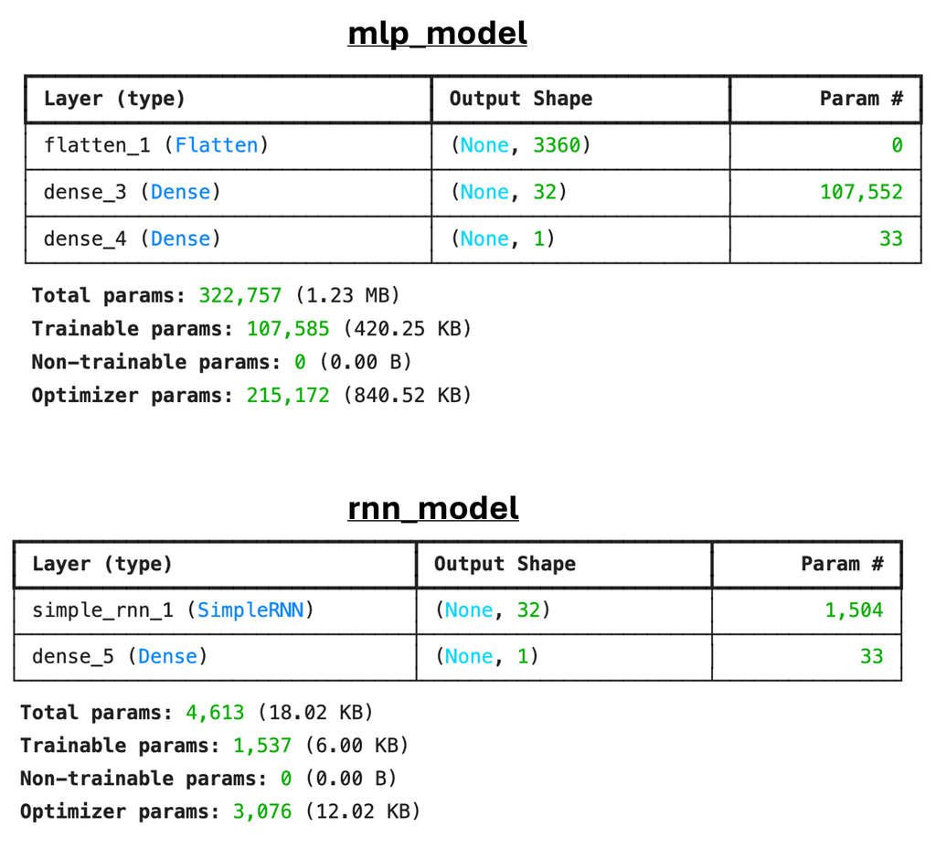

```python
display(Image(filename = 'Lec14_mlp_rnn_models.png', width= 700, height= 700))
```

**The number of parameters in the RNN model (1,537) is 2 order of magnitude lower than the number of parameters in the MLP model (107,585).** This is a main advantage of Recurrent Neural Networks.

Let's rebuild the RNN model:

Data Pre-processing:

```python
data = pd.read_csv('jena_climate_2009_2016.csv')

# Keep only the variables and change to a numpy array
variables = data.columns[1:] #List of variables
data = data.iloc[:,1:].values


# Scale the data relative to the mean and standard deviation of the training data
train_data = data[1:200000,]
mean = np.mean(train_data, axis= 0)
std = np.std(train_data, axis= 0)
data = (data - mean) / std #scale the data
```

Training, testing and validation data generator:

```python
def generator(data, lookback, delay, min_index, max_index=None,
              shuffle=False, batch_size=128, step=6):
    if max_index is None:
        max_index = len(data) - delay - 1
    i = min_index + lookback

    while True:
        if shuffle:
            rows = np.random.randint(min_index + lookback, max_index, size=batch_size)
        else:
            if i + batch_size >= max_index:
                i = min_index + lookback
            rows = np.arange(i, min(i + batch_size, max_index))
            i += len(rows)

        # Create arrays for samples and targets
        samples = np.zeros((len(rows), lookback // step, data.shape[-1]))
        targets = np.zeros(len(rows))

        for j, row in enumerate(rows):
            indices = np.arange(row - lookback, row, step)
            samples[j] = data[indices]
            targets[j] = data[row + delay, 1]  # Assuming target is in column 2

        yield samples, targets

    return samples, targets
```

Use the generator function to build a training generator object:

```python
train_gen = generator(data, lookback=1440, delay= 144, min_index= 0, max_index= 25000,
                    shuffle= True, step= 6, batch_size= 128)
```

Build the RNN model:

```python
# Building a simple RNN model
rnn_model = Sequential()
rnn_model.add(SimpleRNN(32))  # RNN with 32 units; , input_shape=(128,240, 14)
rnn_model.add(Dense(1))  # Output layer

# Compile the model
rnn_model.compile(loss='mse', optimizer='adam')

history = rnn_model.fit(train_gen, epochs=20, steps_per_epoch= 100,
                    batch_size=128)
```

```
100/100 ━━━━━━━━━━━━━━━━━━━━ 2s 12ms/step - loss: 0.3210
100/100 ━━━━━━━━━━━━━━━━━━━━ 1s 12ms/step - loss: 0.1300
100/100 ━━━━━━━━━━━━━━━━━━━━ 1s 12ms/step - loss: 0.1161
100/100 ━━━━━━━━━━━━━━━━━━━━ 1s 12ms/step - loss: 0.1081
100/100 ━━━━━━━━━━━━━━━━━━━━ 1s 12ms/step - loss: 0.1048
100/100 ━━━━━━━━━━━━━━━━━━━━ 1s 12ms/step - loss: 0.0947
100/100 ━━━━━━━━━━━━━━━━━━━━ 1s 12ms/step - loss: 0.0925
100/100 ━━━━━━━━━━━━━━━━━━━━ 1s 12ms/step - loss: 0.0889
100/100 ━━━━━━━━━━━━━━━━━━━━ 1s 12ms/step - loss: 0.0866
100/100 ━━━━━━━━━━━━━━━━━━━━ 1s 12ms/step - loss: 0.0785
100/100 ━━━━━━━━━━━━━━━━━━━━ 1s 12ms/step - loss: 0.0747
100/100 ━━━━━━━━━━━━━━━━━━━━ 1s 12ms/step - loss: 0.0717
100/100 ━━━━━━━━━━━━━━━━━━━━ 1s 12ms/step - loss: 0.0684
100/100 ━━━━━━━━━━━━━━━━━━━━ 1s 12ms/step - loss: 0.0687
100/100 ━━━━━━━━━━━━━━━━━━━━ 1s 12ms/step - loss: 0.0631
100/100 ━━━━━━━━━━━━━━━━━━━━ 1s 12ms/step - loss: 0.0635
100/100 ━━━━━━━━━━━━━━━━━━━━ 1s 12ms/step - loss: 0.0605
100/100 ━━━━━━━━━━━━━━━━━━━━ 1s 12ms/step - loss: 0.0580
100/100 ━━━━━━━━━━━━━━━━━━━━ 1s 12ms/step - loss: 0.0579
100/100 ━━━━━━━━━━━━━━━━━━━━ 1s 12ms/step - loss: 0.0595
```

Plot the training loss curve:

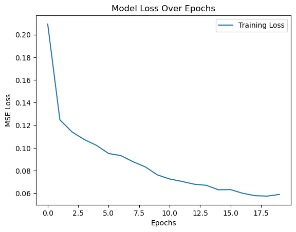

```python
# 3. Plot the loss curve
plt.plot(history.history['loss'], label='Training Loss')
#plt.plot(history.history['val_loss'], label='Validation Loss')
plt.title('Model Loss Over Epochs')
plt.xlabel('Epochs')
plt.ylabel('MSE Loss')
plt.legend()
plt.show()
```

## Techniques used in training ML Models

### 1. The Validation Data Split

The validation data split is a subset of data set aside from the training data, used to evaluate a machine learning model's performance during training. Unlike the test set, which assesses the final model after training is complete, the validation set allows for tuning model hyperparameters and provides insight into how well the model generalizes to unseen data.

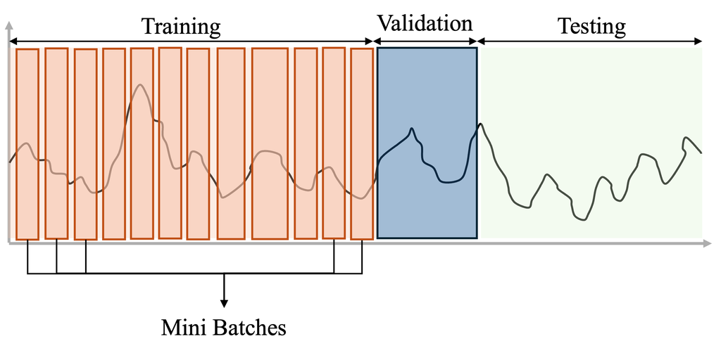

```python
display(Image(filename = 'validation_data_split.png', width= 750, height= 500))
```

Let's implement validation data split in this RNN model:

First, use the generator function to build a validation data generator:

```python
val_gen = generator(data, lookback=1440, delay= 144, min_index= 50001, max_index= 60000,
                    shuffle= True, step= 6, batch_size= 128)

# For illustration only: Get the first batch of samples and targets
X_val, y_val = next(val_gen)
print(X_val.shape)
print(y_val.shape)
```

```
(128, 240, 14)
(128,)
```

```python
# Building a simple RNN model
rnn_model_2 = Sequential()
rnn_model_2.add(SimpleRNN(32))  # RNN with 32 units; , input_shape=(128,240, 14)
rnn_model_2.add(Dense(1))  # Output layer

# Compile the model
rnn_model_2.compile(loss='mse', optimizer='adam')

history = rnn_model_2.fit(train_gen, epochs=20, steps_per_epoch= 100, batch_size=128,
                          validation_data= val_gen, validation_steps= int(np.floor(10000/128)))
```

```
100/100 ━━━━━━━━━━━━━━━━━━━━ 2s 16ms/step - loss: 0.2500 - val_loss: 0.2220
100/100 ━━━━━━━━━━━━━━━━━━━━ 2s 15ms/step - loss: 0.1277 - val_loss: 0.2098
100/100 ━━━━━━━━━━━━━━━━━━━━ 2s 15ms/step - loss: 0.1170 - val_loss: 0.1684
100/100 ━━━━━━━━━━━━━━━━━━━━ 2s 16ms/step - loss: 0.1058 - val_loss: 0.1932
100/100 ━━━━━━━━━━━━━━━━━━━━ 2s 15ms/step - loss: 0.1004 - val_loss: 0.1897
100/100 ━━━━━━━━━━━━━━━━━━━━ 2s 15ms/step - loss: 0.0935 - val_loss: 0.1931
100/100 ━━━━━━━━━━━━━━━━━━━━ 2s 15ms/step - loss: 0.0893 - val_loss: 0.1983
100/100 ━━━━━━━━━━━━━━━━━━━━ 2s 15ms/step - loss: 0.0838 - val_loss: 0.1695
100/100 ━━━━━━━━━━━━━━━━━━━━ 2s 16ms/step - loss: 0.0835 - val_loss: 0.2193
100/100 ━━━━━━━━━━━━━━━━━━━━ 2s 15ms/step - loss: 0.0763 - val_loss: 0.2133
100/100 ━━━━━━━━━━━━━━━━━━━━ 2s 15ms/step - loss: 0.0759 - val_loss: 0.1908
100/100 ━━━━━━━━━━━━━━━━━━━━ 2s 16ms/step - loss: 0.0716 - val_loss: 0.2148
100/100 ━━━━━━━━━━━━━━━━━━━━ 2s 15ms/step - loss: 0.0727 - val_loss: 0.2244
100/100 ━━━━━━━━━━━━━━━━━━━━ 2s 16ms/step - loss: 0.0724 - val_loss: 0.2225
100/100 ━━━━━━━━━━━━━━━━━━━━ 2s 16ms/step - loss: 0.0643 - val_loss: 0.2167
100/100 ━━━━━━━━━━━━━━━━━━━━ 2s 16ms/step - loss: 0.0632 - val_loss: 0.3005
100/100 ━━━━━━━━━━━━━━━━━━━━ 2s 15ms/step - loss: 0.0645 - val_loss: 0.2591
100/100 ━━━━━━━━━━━━━━━━━━━━ 2s 16ms/step - loss: 0.0594 - val_loss: 0.2437
100/100 ━━━━━━━━━━━━━━━━━━━━ 2s 16ms/step - loss: 0.0561 - val_loss: 0.2737
100/100 ━━━━━━━━━━━━━━━━━━━━ 2s 16ms/step - loss: 0.0552 - val_loss: 0.2683
```

Plot both the training and validation loss curves:

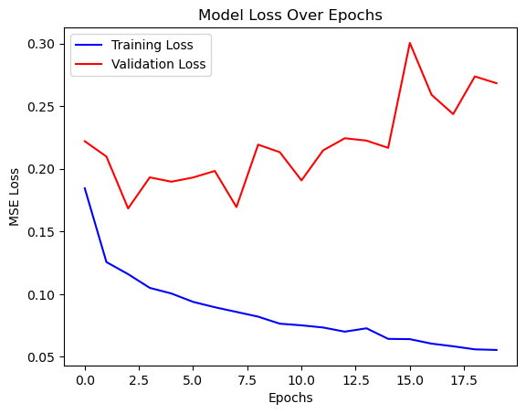

```python
# 3. Plot the loss curve
plt.plot(history.history['loss'], label='Training Loss', c= 'blue')
plt.plot(history.history['val_loss'], label='Validation Loss', c= 'red')
plt.title('Model Loss Over Epochs')
plt.xlabel('Epochs')
plt.ylabel('MSE Loss')
plt.legend()
plt.show()
```

#### Did the validation data split improved the model?

```python
test_gen = generator(data, lookback=1440, delay= 144, min_index= 300001,
                    shuffle= True, step= 6, batch_size= 128)
X_test, y_test = next(test_gen)

# RNN predictions (without validation data)
rnn_pred = rnn_model.predict(X_test)
rnn_pred = rnn_pred*std[1] + mean[1]  #Rescale predictions
rnn_pred = rnn_pred.flatten()

# RNN predictions (with validation data)
rnn2_pred = rnn_model_2.predict(X_test)
rnn2_pred = rnn2_pred*std[1] + mean[1]  #Rescale predictions
rnn2_pred = rnn2_pred.flatten()

# Rescale observations
y_test = y_test*std[1] + mean[1]
```

```
4/4 ━━━━━━━━━━━━━━━━━━━━ 0s 3ms/step
4/4 ━━━━━━━━━━━━━━━━━━━━ 0s 3ms/step
```

```python
print('Model without validation data')
rmse = np.sqrt(np.mean( (y_test - rnn_pred)**2))
print('RMSE = ', np.round(np.sqrt(np.mean( (y_test - rnn_pred)**2)), 2), 'C')
print('NSE = ', np.round(1 - (rmse/np.var(y_test)), 3))
print('Pearson correlation = ', np.round(np.corrcoef(y_test, rnn_pred)[0,1], 3))
print('Relative Bias = ', np.round((np.mean(rnn_pred - y_test)/np.mean(y_test))*100), 3, ' %')

print('-------------------------------------')

print('Model with validation data')
rmse = np.sqrt(np.mean( (y_test - rnn2_pred)**2))
print('RMSE = ', np.round(np.sqrt(np.mean( (y_test - rnn2_pred)**2)), 2), 'C')
print('NSE = ', np.round(1 - (rmse/np.var(y_test)), 3))
print('Pearson correlation = ', np.round(np.corrcoef(y_test, rnn2_pred)[0,1], 3))
print('Relative Bias = ', np.round((np.mean(rnn2_pred - y_test)/np.mean(y_test))*100, 3), ' %')
```

[output not shown]

### 2. Dropout:

Dropout is a regularization technique used to prevent overfitting during training. It works by randomly "dropping out" (setting to zero) a certain percentage of neurons in a layer during each training iteration. This random removal forces the network to learn more robust features and not rely too heavily on any specific neuron, which enhances its generalization on unseen data.

Let's build an RNN model with dropout:

```python
# Building a simple RNN model
rnn_model_3 = Sequential()
rnn_model_3.add(SimpleRNN(32))  # RNN with 32 units; , input_shape=(128,240, 14)
rnn_model_3.add(Dropout(0.1))
rnn_model_3.add(Dense(1))  # Output layer

# Compile the model
rnn_model_3.compile(loss='mse', optimizer='adam')

history = rnn_model_3.fit(train_gen, epochs=20, steps_per_epoch= 100, batch_size=128)
```

```
100/100 ━━━━━━━━━━━━━━━━━━━━ 2s 12ms/step - loss: 1.0997
100/100 ━━━━━━━━━━━━━━━━━━━━ 1s 12ms/step - loss: 0.2234
100/100 ━━━━━━━━━━━━━━━━━━━━ 1s 12ms/step - loss: 0.1777
100/100 ━━━━━━━━━━━━━━━━━━━━ 1s 12ms/step - loss: 0.1595
100/100 ━━━━━━━━━━━━━━━━━━━━ 1s 12ms/step - loss: 0.1440
100/100 ━━━━━━━━━━━━━━━━━━━━ 1s 12ms/step - loss: 0.1398
100/100 ━━━━━━━━━━━━━━━━━━━━ 1s 12ms/step - loss: 0.1316
100/100 ━━━━━━━━━━━━━━━━━━━━ 1s 12ms/step - loss: 0.1242
100/100 ━━━━━━━━━━━━━━━━━━━━ 1s 12ms/step - loss: 0.1189
100/100 ━━━━━━━━━━━━━━━━━━━━ 1s 12ms/step - loss: 0.1148
100/100 ━━━━━━━━━━━━━━━━━━━━ 1s 12ms/step - loss: 0.1155
100/100 ━━━━━━━━━━━━━━━━━━━━ 1s 12ms/step - loss: 0.1060
100/100 ━━━━━━━━━━━━━━━━━━━━ 1s 12ms/step - loss: 0.1055
100/100 ━━━━━━━━━━━━━━━━━━━━ 1s 12ms/step - loss: 0.1028
100/100 ━━━━━━━━━━━━━━━━━━━━ 1s 12ms/step - loss: 0.0977
100/100 ━━━━━━━━━━━━━━━━━━━━ 1s 12ms/step - loss: 0.1005
100/100 ━━━━━━━━━━━━━━━━━━━━ 1s 12ms/step - loss: 0.0966
100/100 ━━━━━━━━━━━━━━━━━━━━ 1s 12ms/step - loss: 0.0926
100/100 ━━━━━━━━━━━━━━━━━━━━ 1s 12ms/step - loss: 0.0933
100/100 ━━━━━━━━━━━━━━━━━━━━ 1s 12ms/step - loss: 0.0887
```

Compare the models:

```python
# RNN predictions (with dropout)
rnn3_pred = rnn_model_3.predict(X_test)
rnn3_pred = rnn3_pred*std[1] + mean[1]  #Rescale predictions
rnn3_pred = rnn3_pred.flatten()

preds = [rnn_pred, rnn2_pred, rnn3_pred]
metrics = pd.DataFrame(np.empty((4,4)), index= ['RMSE', 'NSE', 'Pearson_cc', 'Rel_Bias'],
                       columns = ['RNN', 'RNN_w_val', 'RNN_w_drop', 'RNN_w_val_drop'])
for i in range(len(preds)):
    rmse = np.sqrt(np.mean( (y_test - preds[i])**2))
    nse = np.round(1 - (rmse/np.var(y_test)), 3)
    pearson = np.round(np.corrcoef(y_test, preds[i])[0,1], 3)
    rel_bias = np.round((np.mean(preds[i] - y_test)/np.mean(y_test))*100, 3)
    metrics.iloc[:,i] = np.array([rmse, nse, pearson, rel_bias])

metrics
```

```
4/4 ━━━━━━━━━━━━━━━━━━━━ 0s 3ms/step
```

|  | RNN | RNN_w_val | RNN_w_drop | RNN_w_val_drop |
| --- | --- | --- | --- | --- |
| RMSE | 4.07631 | 3.862561 | 3.696969 | 0.0 |
| NSE | 0.91300 | 0.918000 | 0.921000 | 0.0 |
| Pearson_cc | 0.81100 | 0.827000 | 0.844000 | 0.0 |
| Rel_Bias | -6.47300 | -2.573000 | -3.718000 | 0.0 |

## The Vanishing / Exploding Gradient Problem

A common challenge in training deep neural networks, especially recurrent neural networks (RNNs). It arises during backpropagation through time (BPTT), the process used to train RNNs, and can significantly impact the model’s ability to learn long-term dependencies.

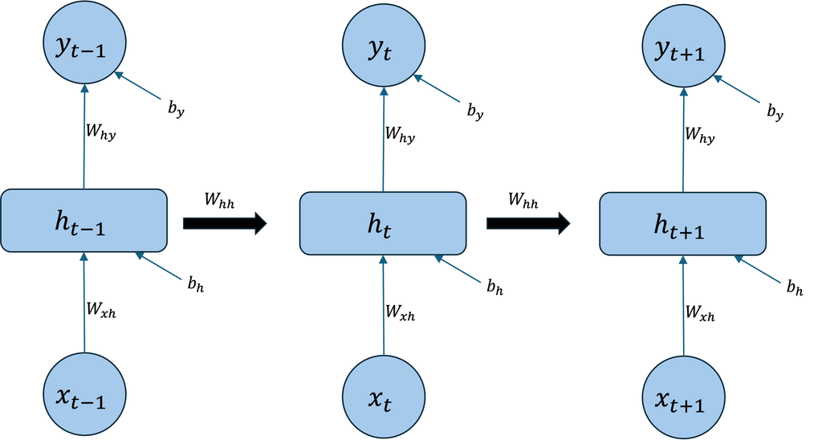

```python
display(Image(filename = 'RNN_unfolded.png', width= 750, height= 600))
```

## In-class Excercise

Build an RNN model using the "monthly_meteo_streamflow.csv" dataset.

- The model will utilize 8 predictors (P, E, ... vpdmin) to forecast streamflow (S) one month ahead.
- Use a lookback period of 12 months.
- Normalize the data (z-score normalization) before using it.
- Build a recurrent neural network with 20 nodes in the hidden layer.
- Compute RMSE and relative bias of the model.
- Test whether validation and dropout can improve the performance of the model.

```python
data = pd.read_csv('monthly_meteo_streamflow.csv')
data
```

|  | year | month | P | E | Tmean | Tmax | Tmin | Tdmean | vpdmax | vpdmin | S |
| --- | --- | --- | --- | --- | --- | --- | --- | --- | --- | --- | --- |
| 0 | 1980 | 1 | 336.051600 | 19.272449 | 4.622550 | 8.745250 | 0.500800 | -3.860550 | 6.400100 | 1.616000 | 423.612903 |
| 1 | 1980 | 2 | 418.161899 | 29.872766 | 5.514000 | 10.940600 | 0.088350 | -5.081450 | 8.782650 | 1.898050 | 1685.965517 |
| 2 | 1980 | 3 | 154.332850 | 58.054099 | 4.030850 | 9.760900 | -1.698250 | -5.708050 | 8.087550 | 1.454300 | 609.161290 |
| 3 | 1980 | 4 | 19.936850 | 115.392255 | 8.772800 | 16.275450 | 1.271500 | -5.285750 | 15.164100 | 2.414800 | 236.533333 |
| 4 | 1980 | 5 | 26.090900 | 116.888575 | 8.761500 | 15.231000 | 2.293150 | 0.081100 | 11.650450 | 1.135850 | 174.290323 |
| ... | ... | ... | ... | ... | ... | ... | ... | ... | ... | ... | ... |
| 499 | 2021 | 8 | 3.187385 | 152.323303 | 21.948775 | 27.692679 | 16.205010 | 4.492985 | 29.707269 | 9.432910 | 0.425161 |
| 500 | 2021 | 9 | 0.694000 | 112.327974 | 19.826580 | 25.139330 | 14.513980 | 1.894015 | 26.081899 | 7.880130 | 0.536333 |
| 501 | 2021 | 10 | 34.804679 | 80.789519 | 10.903875 | 17.622540 | 4.185345 | -2.362750 | 13.043130 | 3.043920 | 1.584839 |
| 502 | 2021 | 11 | 0.000000 | 50.394858 | 11.795860 | 16.642759 | 6.949110 | -6.681535 | 15.416895 | 5.452640 | 2.848667 |
| 503 | 2021 | 12 | 232.752304 | 23.204832 | 4.356815 | 8.752690 | -0.038955 | -6.133355 | 8.025990 | 2.356045 | 151.384194 |

504 rows × 11 columns